# Eigenfaces: Principal Component Analysis and Dimensionality Reduction

### Daniel Nghiem

### Mathematics Instructor, Foothill College

#### nghiemdaniel@fhda.edu

# Loading the dataset of faces

- Taken from AT&T Laboratories Cambridge: http://www.cl.cam.ac.uk/research/dtg/attarchive/facedatabase.htmlTen
- Different images of each of 40 distinct subjects
- Some images were taken at different times, varying the lighting, facial expressions (open / closed eyes, smiling / not smiling) and facial details (glasses / no glasses).
- All the images were taken against a dark homogeneous background with the subjects in an upright, frontal position (with tolerance for some side movement).

```python
import numpy as np
import sklearn
from sklearn import datasets
import matplotlib.pyplot as plt
%matplotlib inline

# For my reference:  To turn jupyter notebook into slides, type in terminal:
# jupyter nbconvert eigenface_notebook.ipynb --to slides --post serve
```

```python
# Load face images and their target labels
# Images are from AT&T Laboratories Cambridge
# http://www.cl.cam.ac.uk/research/dtg/attarchive/facedatabase.html

dataset = sklearn.datasets.fetch_olivetti_faces()

faces_data = dataset.data
faces_images = dataset.images
target = dataset.target          # Labels for each image, ranging from 0-39,
                                 # one for each distinct person.

target_classes = np.unique(target)
```

```python
print(faces_images.shape)
print(faces_data.shape)
print(target_classes)
```

```
(400, 64, 64)
(400, 4096)
[ 0  1  2  3  4  5  6  7  8  9 10 11 12 13 14 15 16 17 18 19 20 21 22 23
 24 25 26 27 28 29 30 31 32 33 34 35 36 37 38 39]
```

```
[[0.2107438  0.20661157 0.19421488 ... 0.38842976 0.16115703 0.09917355]
 [0.21487603 0.2107438  0.18595041 ... 0.62396693 0.30578512 0.10743801]
 [0.2231405  0.2107438  0.1983471  ... 0.78512394 0.5123967  0.19008264]
 ...
 [0.2107438  0.2107438  0.21487603 ... 0.54545456 0.39256197 0.21487603]
 [0.2107438  0.2107438  0.21487603 ... 0.5371901  0.38016528 0.21900827]
 [0.2107438  0.21487603 0.21487603 ... 0.54545456 0.35950413 0.21900827]]
```

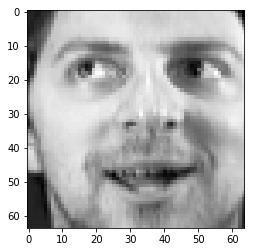

```python
# Here is an example image in array (matrix) form.  Pixel values are
# within the range [0, 1], where 0 is black and 1 is white.

im = faces_images[65]
print (im)

# And in image form
fig = plt.figure(figsize=(4,4))
plt.imshow(im, cmap='gray')
```

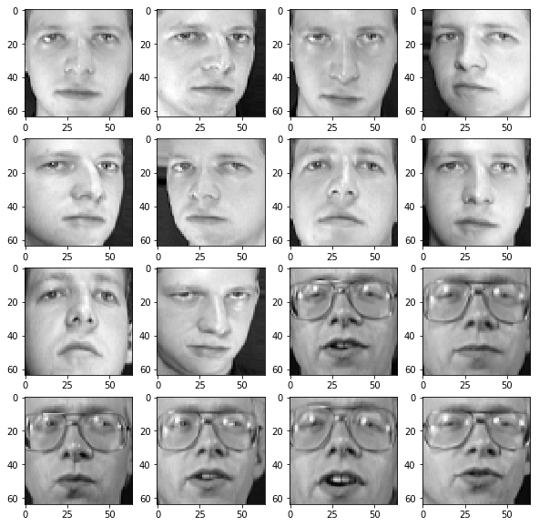

```python
# Here are the first 16 images.  Note the slight variations in the eyes,
# lips, and angles of the face.

fig, axes = plt.subplots(4, 4, figsize=(10,10))

for i, ax in enumerate(axes.flat):
    im = faces_images[i]
    ax.imshow(im, cmap='gray')
```

# Applying Principal Component Analysis

[figure not shown]

Diagram taken from https://stats.stackexchange.com/questions/2691/making-sense-of-principal-component-analysis-eigenvectors-eigenvalues

```python
from time import time
import logging
from sklearn.model_selection import train_test_split
```

```python
# Split the image data into training and testing sets using
# a 80%-20% split.  We won't perform any classification in this project,
# but we will use an image from Xtest later.

Xtrain, Xtest, ytrain, ytest = train_test_split(
    faces_data, target, test_size=0.2, random_state=34
    )

n_samples = faces_data.shape[0]
n_features = faces_data.shape[1]

print("Number of samples: %d" % n_samples)
print("Number of features (pixels): %d" % n_features)
print("Number of classes: %d" % len(target_classes))
print(" ")
print("Length of Xtrain:",len(Xtrain))
print("Length of Xtest:",len(Xtest))
print("Length of ytrain:",len(ytrain))
print("Length of ytest:",len(ytest))
```

```
Number of samples: 400
Number of features (pixels): 4096
Number of classes: 40

Length of Xtrain: 320
Length of Xtest: 80
Length of ytrain: 320
Length of ytest: 80
```

# Looking at the Xtrain images

- A random sample of the original 400 images that represent 40 people
- Slight variation of facial expressions for each person

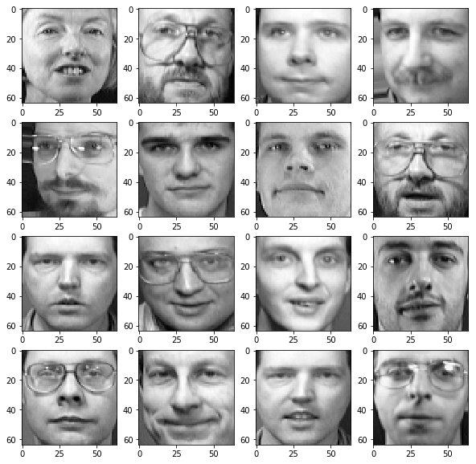

```python
fig, axes = plt.subplots(4, 4, figsize=(10,10))

for i, ax in enumerate(axes.flat):
    im = Xtrain[i].reshape(64,64)
    ax.imshow(im, cmap='gray')
```

# PCA Step 1: Subtract the mean face to center the image data

[figure not shown]

As the illustration here shows, before we find a new representation of the data in a new coordinate system, we first need to center the new set of axis on the data set.

This is done by subtracting the average face from each image vector. Let $x_{k}^{(i)}$ represent the $k^{th}$ pixel value in the $i^{th}$ image vector. Then the $k^{th}$ pixel value in the mean face is $\overline{x}_{k} = \dfrac{1}{n}\Sigma_{i=0}^{n}x_{k}^{(i)}$.

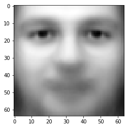

```python
mean_face = Xtrain.sum(axis=0) / Xtrain.shape[0]

fig = plt.figure(figsize=(4,4))
plt.imshow(mean_face.reshape(64,64), cmap='gray')
```

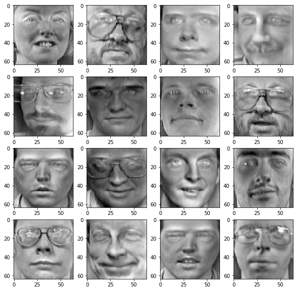

```python
Xtrain_centered = Xtrain.reshape(320, 64, 64) - mean_face.reshape(64,64)

fig, axes = plt.subplots(4, 4, figsize=(10,10))
for i, ax in enumerate(axes.flat):
    ax.imshow(Xtrain_centered[i], cmap='gray')
```

# Step 2: Create the Covariance Matrix

-The sample covariance of two ramdom variables is defined by

$Cov(X,Y) = \dfrac{1}{n-1}\Sigma(X-\overline{X})(Y-\overline{Y})$

where $\overline{X}$ and $\overline{Y}$ are the sample averages of $X$ and $Y$, respectively.

-The 2x2 covariance matrix is given by \begin{bmatrix} Cov(X,X) & Cov(X,Y) \\ Cov(Y,X) & Cov(Y,Y) \end{bmatrix}

-If the matrix $B$ has columns of the form $x^{(i)} - \overline{x}$, where $x^{(i)}$ is feature vector with length `n_features`, and $\overline{x}$ is the average of all feature vectors, then $\dfrac{1}{n-1}B^tB$ is an $n $ x $n$ covariance matrix for all the features in the data.

```python
reshaped = Xtrain_centered.reshape(320, 4096)

covariance = 1.0/319*np.dot(np.transpose(reshaped), reshaped)

print(covariance.shape)
```

```
(4096, 4096)
```

```python
print(covariance)
```

```
[[ 0.03378705  0.03316962  0.02914113 ... -0.00649895 -0.0068785
  -0.00511559]
 [ 0.03316962  0.03674223  0.0346547  ... -0.00935969 -0.00974777
  -0.00760428]
 [ 0.02914113  0.0346547   0.03852506 ... -0.01289953 -0.01289989
  -0.01065755]
 ...
 [-0.00649895 -0.00935969 -0.01289953 ...  0.03580235  0.03278019
   0.02943966]
 [-0.0068785  -0.00974777 -0.01289989 ...  0.03278019  0.03499561
   0.03247105]
 [-0.00511559 -0.00760428 -0.01065755 ...  0.02943966  0.03247105
   0.03382682]]
```

# Step 3: Diagonalize the covariance matrix and find all eigenvectors

```python
from numpy.linalg import eig

evalues, evectors = eig(covariance)    # The evectors is a matrix whose columns
                                       # are the eigenvectors of the covariance matrix.

print(evalues)
print(evectors.shape)
```

```
[ 1.8166409e+01  1.1527803e+01  5.9369287e+00 ... -2.4713416e-09
 -2.4636524e-09 -1.5319341e-09]
(4096, 4096)
```

```
(4096,)
```

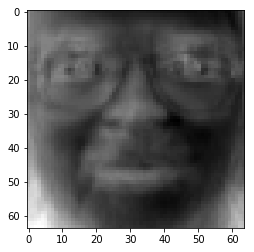

```python
# Display the first eigenvector...call it an Eigenface!

v = evectors[:,0]
print(v.shape)

fig = plt.figure(figsize=(4,4))
plt.imshow(v.reshape(64,64), cmap='gray')
```